# 201803430 조성현

### 1.

어느공장에서 생산하는 부품에 대하여 무게를 측정하여 다음과 같은자료를 얻었다. 평균, 중앙값, 표준편차,왜도,첨도를 구하는 프로그램을 작성하여 값들을 구하시오.

```
10.21   10.53   9.99    11.11   10.47   10.48   10.25   10.63   11.07   10.61
10.33   10.01   11.20   10.41   10.33   10.12   10.78   10.91   10.37   9.58
```

#### 답:

평균: 10.47

중앙값: 10.44

표준편차: 0.408

왜도: 0.003

첨도: 2.747

### 2.

다음은 어느대학에서 개설된 교양 통계학 강좌를 수강한 학생들의 학년별 성적자료이다. 성적의 변수명은 score, 학년의 변수명은 level (L=1학년, H=2,3,4학년)로 지정하여 다음 문제를 해결하시오

```
1학년: 88,67,77,75,84,90,95,73,69,80,79,82,95,62
2학년: 82,86,88,92,77,72,96,75,68,96,85,86,76,89,83
```

1. 학년별 성적자료에 대한 기술통계량을 산출하시오.

```r
#기술통계량 산출을 위한 라이브러리 호출
library(mosaic)
# 1학년들의 기술 통계
favstats(df1$score,df1)
```

```
##  min   Q1 median Q3 max     mean       sd  n missing
##   62 73.5   79.5 87  95 79.71429 10.11799 14       0
```

```r
# 2학년들의 기술통계
favstats(df2$score,df2)
```

```
##  min   Q1 median   Q3 max mean       sd  n missing
##   68 76.5     85 88.5  96 83.4 8.432929 15       0
```

2. 히스토그램과 상자그림을 작성하시오.

학년 각각의 히스토그램

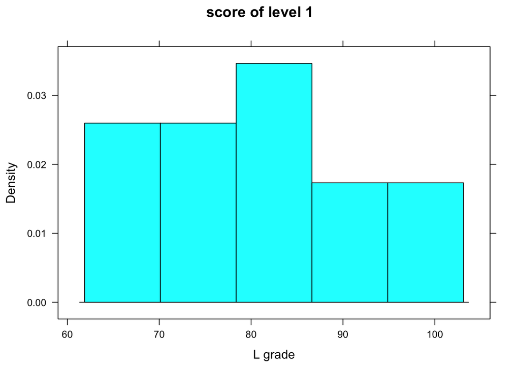

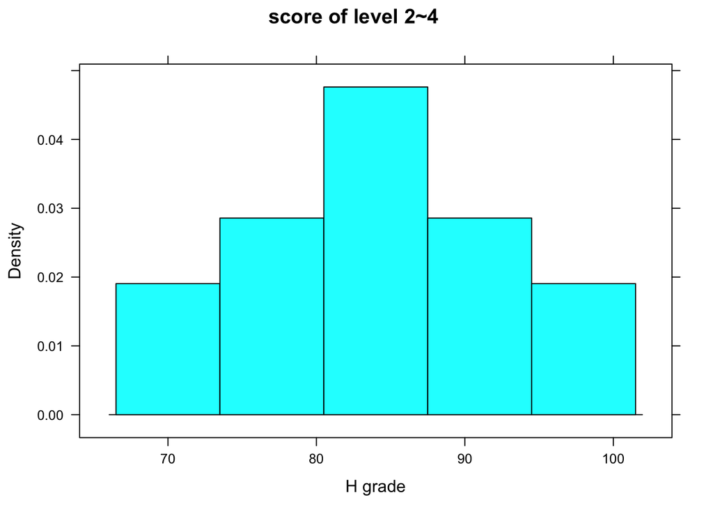

학년 각각의 상자그림

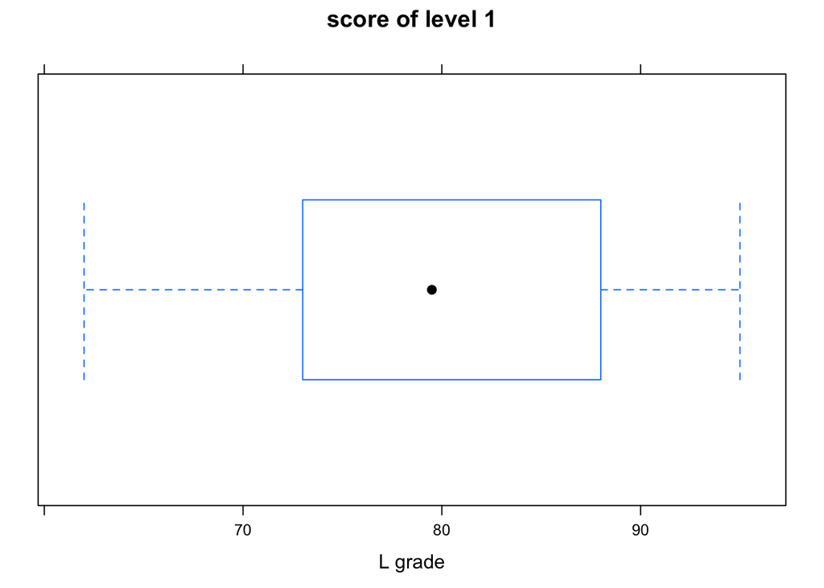

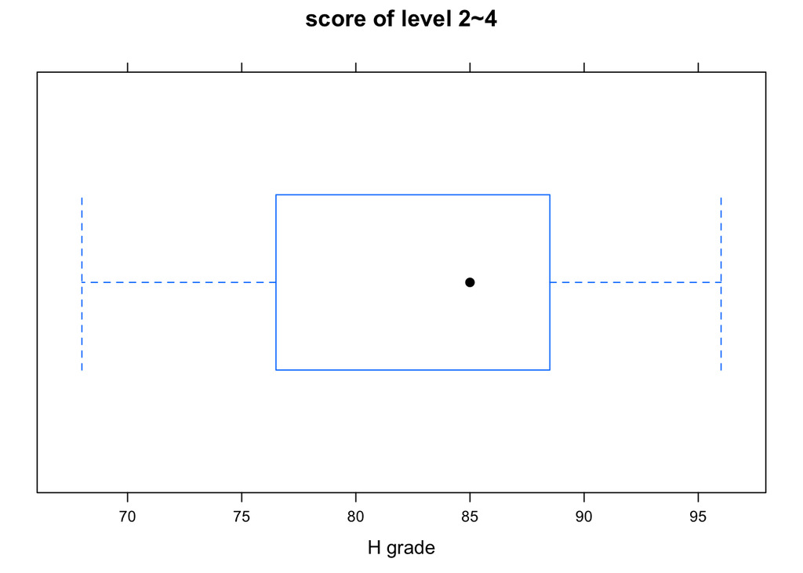

3. 위의 자료가 정규분포를 따른다고 할수 있는지 설명하시오.

먼저 1학년의 자료와 2~ 4학년의 자료의 점규성 검정을 한다고 하면,

1학년과 2~4학년의 자료의 수가 각각 100 개를 넘지 못하는 소표본 이다.

자료가 정규 분포를 따른 다는 귀무 가설을 가정하자. Shapiro-Wilk normality test 와 Anderson-Darling 정규성 검정법을 사용한다.

```
##
##  Shapiro-Wilk normality test
##
## data:  df1$score
## W = 0.97324, p-value = 0.9168
```

```
##
##  Shapiro-Wilk normality test
##
## data:  df2$score
## W = 0.96584, p-value = 0.7924
```

1학년 자료의 p-value 는 0.916 이며, 2~4 학년의 p-value 는 0.792이다.

두자료 모두 통계랑(W)과 p 값인(p-value) 유의 확률이 모두 0.05 보다 크다.

```
##
##  Anderson-Darling normality test
##
## data:  df1$score
## A = 0.12943, p-value = 0.9764
```

```
##
##  Anderson-Darling normality test
##
## data:  df2$score
## A = 0.20493, p-value = 0.8428
```

통계랑(A)과 p 값인(p-value) 유의 확률이 모두 0.05 보다 크다.

그렇므로 검정통계량으로 확인한 바에 따라 귀무 가설을 채택한다.

#### 따라서 두개의 자료모두 정규성을 따르며 정규분포를 따른다.

다음은 전 학생(29명)의 성적의 검정이다. 귀무 가설은 및 검정법은 위와 동일하다.

```
##
##  Shapiro-Wilk normality test
##
## data:  dfscore$score
## W = 0.972, p-value = 0.6151
```

```
##
##  Anderson-Darling normality test
##
## data:  dfscore$score
## A = 0.19453, p-value = 0.8841
```

통계랑(A,w)와 p 값인(p-value) 유의 확률이 모두 0.05 보다 크다.

그렇므로 검정통계량으로 확인한 바에 따라 귀무 가설을 채택한다.

따라서 전체 학생의 자료도 정규 분포를 따른다.

추가 자료

다음은 점들이 직선에 유사할때 정규성을 보이는지 확인하는 QQ plot 이다.

1학년

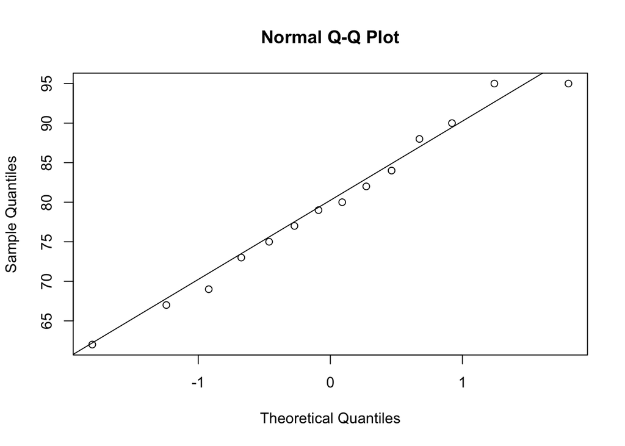

2~4 학년

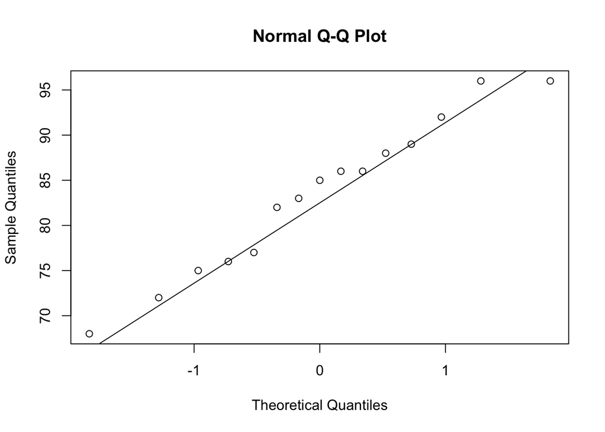

모든학생

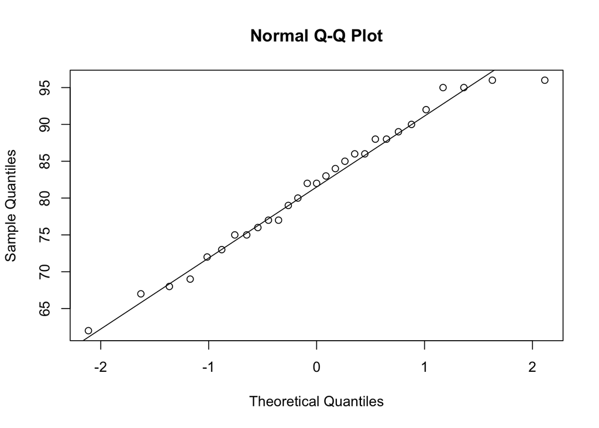

4. 학년별 평균, 표준편차, 최대값, 최소값을 구하시오.

1학년

평균:79.714 표준편차:10.118 최댓값:95 최솟값:62

2~4학년

평균:83.4 표준편차:8.433 최댓값:96 최솟값:68

5. 전체 성적자료에 대한 상자그림을 그리시오. 이때, 이상치가 존재하는지를 살펴볼수있는 상자그림을 작성하고, 이상치가 존재한다고 할수 있는지 설명하시오.

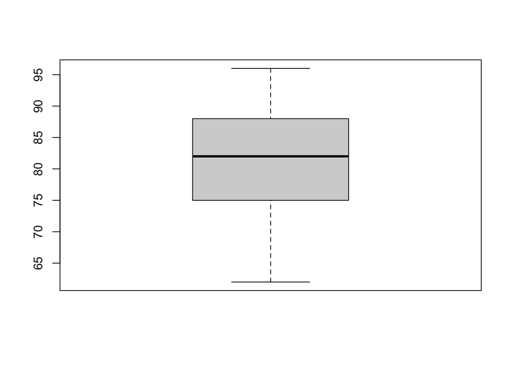

이상치란 다른 데이터보다 아주 작은 값이나 아주 큰 값을 말한다.

box-plot(그림상자)은 사분위수를 보여주는 특징이 있다.

1분위수의 위치는 상자의 가로 하단 변이며 ,3분위수의 위치는 상자 가로 윗변이다.

자료의 범위는 최상단과 최하단의 실선 차이이며 이는 각각 사분위수를 포함한 최댓값과 최솟값이다.

위 상자의 사분위수를 포함하는 최댓값과 최솟값을 벗어나는 자료가 없으므로

전체 성적 자료는 이상치가 존재 하지 않는다.

### 3.

어느 대기업에서는 특정 중소기업으로부터 부품을 납품받고 있다. 이 부품의 납품서에 의하면 부품의 평균 지름은 12.5cm 라고 한다. 이 대기업에서는 부품의 지름이 실제로 납품서에 적혀 있는 값과 동일한 지를 검사하기 위해서 30개의 부품을 임으로 추출하여 지름을 측정한 결과, 다음과 같은 결과를 얻었다.

```
12.5  12.6  12.5  12.4  12.6    12.8    12.3  12.6  12.4    12.5
12.8  12.5  12.4    12.6  12.7  12.5    12.4  12.5  12.3    12.6
12.6  12.4  12.7  12.5  12.5    12.6    12.5  12.7  12.4    12.6
```

부품의 평균지름이 납품서와 같다고 할 수 있는지를 유의수준 5%에서 검정하시오.

30 개의 자료를 가진 표본이므로 정규성을 먼저 검사한다. Shapiro-Wilk normality test를 사용하며 자료가 정규성을 가진다는 귀무 가설을 가정한다..

```
##
##  Shapiro-Wilk normality test
##
## data:  df$diameter
## W = 0.94083, p-value = 0.09575
```

p-value 가 0.05 를 넘으므로 귀무가설을 기각하지 못한다

위자료가 정규성을 가진다는 사실을 알았으니 유의수준 5%에서 T-검정을 한다. 먼저 다음과 같은 가설을 세운다.

귀무 가설 : 부품의 납품서에 의한 부품지름과 30개를 임의 추출한 지름의 평균(12.5cm)이 같다

H(0): μ = 12.5

```
##
##  One Sample t-test
##
## data:  df$diameter
## t = 1.4094, df = 29, p-value = 0.1694
## alternative hypothesis: true mean is not equal to 12.5
## 95 percent confidence interval:
##  12.48496 12.58171
## sample estimates:
## mean of x
##  12.53333
```

95 percent confidence interval: <- 95% 신뢰 구간 안에 귀무가설의 값 12.5 를 포함한다.

그렇므로 귀무가설을 기각하지 않고, 체택한다.

그렇므로 결론:

#### 부품의 평균지름이 납품서와 같다